# Projekt 1, faza 2

Michal Frej, Bartosz Piotrowski, Krzysztof Rutkowski

# Czyszczenie i przygotowywanie danych

Na samym poczatku przeprowadzamy wstepna obrobke danych, by uzyskac tabele, na ktorej bedziemy przeprowadzali analizy.

Wczytujemy tabele i przygotowujemy tak, by wykonac “JOINa” dwoch tabel wzgledem klucza, ktorym jest id pacjenta. Nastepnie nazywamy odpowiednio kolumny otrzymanej tabeli (trzymamy w niej w wierszach pacjentow i dla kazdego pacjenta wiek, plec, grupe raka i ekspresje odpowiednich genow)

```r
setwd("~/Pobrane")
library(lmtest)
library(car)

################################### preparing and cleaning tables ###################################################

load("expression.cb1.rda")
load("expression.cb2.rda")
load("clinical.cb.rda")

expression <- rbind(expression.cb1, expression.cb2)

expression[1:5,1:5] #checking
```

```
##        Sample TCGA.AR.A1AH.01 TCGA.A5.A0GI.01 TCGA.BP.4165.01
## 1 ?|100133144        0.873126        1.160000              NA
## 2 ?|100134869       -0.380000       -0.332584           -1.27
## 3     ?|10357        0.220000        1.112895           -0.39
## 4     ?|10431        1.360000        0.119982            0.09
## 5    ?|155060       -0.030000        2.491257            0.63
##   TCGA.CJ.4876.01
## 1       -0.896874
## 2              NA
## 3       -0.300000
## 4        0.510000
## 5       -0.950000
```

```r
clinical.cb[1:5,1:5] #checking
```

```
##          sampleID X_EVENT   X_INTEGRATION X_OS X_OS_IND
## 1 TCGA-02-0001-01       1 TCGA-02-0001-01  358        1
## 2 TCGA-02-0003-01       1 TCGA-02-0003-01  144        1
## 3 TCGA-02-0004-01       1 TCGA-02-0004-01  345        1
## 4 TCGA-02-0006-01       1 TCGA-02-0006-01  558        1
## 5 TCGA-02-0007-01       1 TCGA-02-0007-01  705        1
```

```r
clinical.cb[,1] <- gsub("\\-", "\\.", clinical.cb[,1])

expression_tmp <- t(expression[,-1])
expression_tmp <- as.data.frame(expression_tmp)

colnames(expression_tmp) <- expression[,1]

expression_tmp <- cbind(rownames(expression_tmp), expression_tmp)

colnames(expression_tmp)[1] <- "PatientID"
colnames(clinical.cb)[1] <- "PatientID"

#merging tables
merged_table <- merge(expression_tmp, clinical.cb[,c("PatientID", "gender", "age_at_initial_pathologic_diagnosis", "X_cohort")], by="PatientID")

colnames(merged_table) <- gsub("\\?\\|","G", colnames(merged_table))
colnames(merged_table) <- gsub("\\-","", colnames(merged_table))
colnames(merged_table) <- gsub("\\,","", colnames(merged_table))
colnames(merged_table) <- gsub(" ","", colnames(merged_table))

merged_table[,"X_cohort"] <- as.factor(merged_table[,"X_cohort"])
merged_table[,"gender"] <- as.factor(merged_table[,"gender"])
```

Nastepnie sprawdzamy licznosci odpowiednich grup rakowych.

```r
#checking amount of cancer types and sizes of groups of observations
sapply(levels(merged_table$X_cohort), function(i) {sum(i==merged_table$X_cohort)})
```

```
##                          TCGA Acute Myeloid Leukemia
##                                                  173
##                                  TCGA Bladder Cancer
##                                                  122
##                                   TCGA Breast Cancer
##                                                  840
##                                    TCGA Colon Cancer
##                                                  190
##                             TCGA Endometrioid Cancer
##                                                  370
## TCGA Formalin Fixed Paraffin-Embedded Pilot Phase II
##                                                   12
##                                    TCGA Glioblastoma
##                                                  166
##                            TCGA Head and Neck Cancer
##                                                  303
##                     TCGA Kidney Clear Cell Carcinoma
##                                                  476
##                             TCGA Lung Adenocarcinoma
##                                                  352
##                    TCGA Lung Squamous Cell Carcinoma
##                                                  258
##                                  TCGA Ovarian Cancer
##                                                  265
##                                   TCGA Rectal Cancer
##                                                   72
```

Okazalo sie, ze jednej z grup jest zdecydowanie mniej niz pozostalych, ma ona maly wplyw na wyniki i moglaby zaburzyc wyniki np testu Tukeya, dla ktorego dane powinny byc zrownowazone. Usuwamy wiec te kolumne.

```r
cleaned_table <- merged_table[-which(merged_table$X_cohort=="TCGA Formalin Fixed Paraffin-Embedded Pilot Phase II"),]
```

Usuwamy pacjentow, ktorzy nie podali plci lub wieku.

```r
# cleaning
cleaned_table <- cleaned_table[-which(cleaned_table$gender == ""),]
cleaned_table <- cleaned_table[-which(is.na(cleaned_table$age_at_initial_pathologic_diagnosis)),]
cleaned_table <- droplevels(cleaned_table)
```

Nie zaburzyla ona licznosciami grup rakowych. Patrzymy jak uklada sie wiek pacjentow.

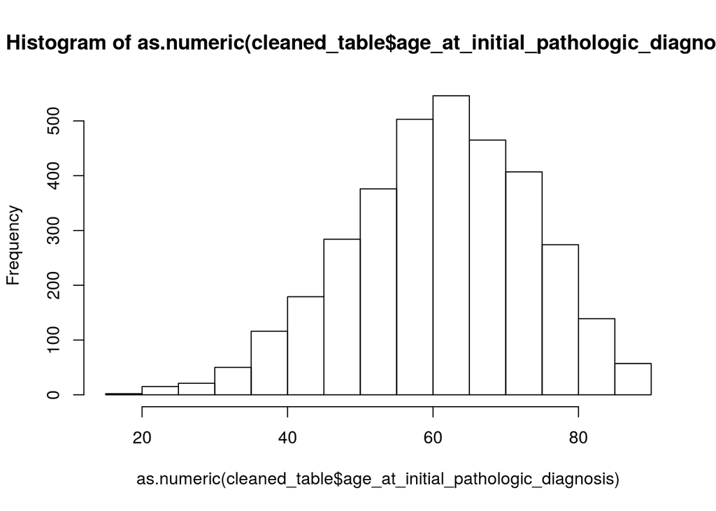

```r
hist(as.numeric(cleaned_table$age_at_initial_pathologic_diagnosis))
```

Wiek jest zmienna ilosciowa, aby wykonac potem analize wariancji dla wieku jako zmiennej jakosciowej wykonamy dyskretyzacje tej zmiennej, dzielac na 18 podobnej licznosci (wg kolejnych kwantyli) grup wiekowych.

```r
#discretization of age column
groups <- quantile(cleaned_table$age_at_initial_pathologic_diagnosis, probs=((0:18)/18))
discrete_age <- as.factor(unlist(lapply(cleaned_table$age_at_initial_pathologic_diagnosis, function(a) {groups[findInterval(a, groups)]})))
cleaned_table$discrete_age <- discrete_age
levels(cleaned_table$discrete_age)
```

```
##  [1] "18" "40" "45" "49" "52" "54" "57" "59" "60" "62" "64" "66" "68" "70"
## [15] "72" "74" "77" "81" "90"
```

# Dopasowanie do danych modelu wielowymiarowej analizy wariancji

Dla tak przeczyszczonych i przygotowanych danych mozemy wykonac teraz wielokierunkowa analize wariancji. Wykonamy ja wzgledem trzech grup jakosciowych: grupy rakowej, wieku i plci. Zbadamy czy zachodza interakcje miedzy grupami grupy rakowej i plci, grupy rakowej i wieku oraz grupy rakowej, wieku i plci. Zbadamy w ten sposob czy pewne grupy wiekowe czy plec daja nam dodatkowa informacje dotyczaca grupy rakowej poza ekspresja genu.

```r
################################### performing ANOVA ###################################################

pvalue_row <- function(i){
  anova(lm(cleaned_table[,i]~X_cohort*discrete_age*gender, data=cleaned_table))[1:7,5]
}

##pvalues <- matrix(unlist(lapply(2:(ncol(cleaned_table)-4),pvalue_row)),ncol=7,byrow=T)
load("pvalues.RData")

#naming pvalues matrix
colnames(pvalues) <- rownames(anova(lm(cleaned_table[,1000]~X_cohort*discrete_age*gender, data=cleaned_table)))[1:7]
rownames(pvalues) <- colnames(cleaned_table)[2:(ncol(cleaned_table)-4)]

#cleaning pvalues matrix
pvalues <- pvalues[-which(is.na(pvalues[,7])),]

head(pvalues)
```

```
##                 X_cohort discrete_age     gender X_cohort:discrete_age
## G100133144  3.224435e-72    0.6007365 0.70931134           0.413718665
## G100134869 3.622352e-140    0.7940368 0.94721828           0.475488317
## G10357      0.000000e+00    0.1995418 0.07149669           0.723247595
## G10431     8.815736e-246    0.3148517 0.51040934           0.009611147
## G155060    2.470119e-259    0.1021672 0.42837832           0.926670537
## G390284     0.000000e+00    0.4502550 0.56830944           0.771565765
##            X_cohort:gender discrete_age:gender
## G100133144       0.5383199           0.4685574
## G100134869       0.4060107           0.2271692
## G10357           0.6808086           0.8274321
## G10431           0.7909549           0.3945949
## G155060          0.4842506           0.0389547
## G390284          0.1034836           0.4043956
##            X_cohort:discrete_age:gender
## G100133144                    0.5954834
## G100134869                    0.2878391
## G10357                        0.5145662
## G10431                        0.7302850
## G155060                       0.6029267
## G390284                       0.8602705
```

Odczytujemy teraz interesujace histogramy p-wartosci kolejnych analiz: grupa rakowa, grupy rakowej i plci, grupy rakowej i wieku oraz grupy rakowej, wieku i plci.

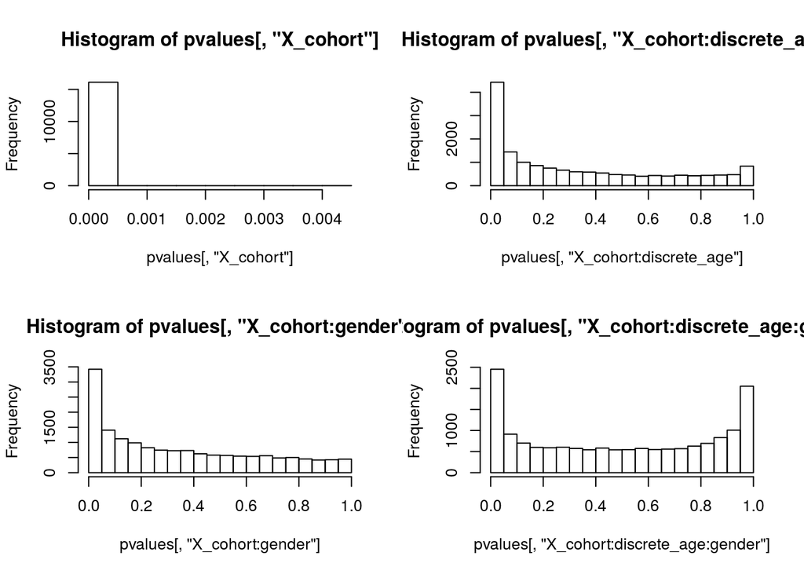

```r
par(mfrow=c(2,2))
hist(pvalues[,"X_cohort"])
hist(pvalues[,"X_cohort:discrete_age"])
hist(pvalues[,"X_cohort:gender"])
hist(pvalues[,"X_cohort:discrete_age:gender"])
```

Widzimy, ze dla interakcji wychodza male p-wartosci, bedziemy teraz sprawdzac, dla ktorych genow mamy mala p-wartosc hipotezy o interakcji oraz spelnione sa zalozenia modelu. Wybieramy geny, dla ktorych jest mala p-wartosc dla interakcji odpowiednich grup.

```r
#extracting genes with low pvalues
rownames(anova(lm(cleaned_table[,1000]~X_cohort*discrete_age*gender, data=cleaned_table)))[1:7]
```

```
## [1] "X_cohort"                     "discrete_age"
## [3] "gender"                       "X_cohort:discrete_age"
## [5] "X_cohort:gender"              "discrete_age:gender"
## [7] "X_cohort:discrete_age:gender"
```

```r
best1 <- names(which((pvalues[,4] < 0.01)*(pvalues[,5] < 0.01)*(pvalues[,7] < 0.01)==1))
length(best1)
```

```
## [1] 80
```

```r
best2 <- names(which((pvalues[,4] < 0.005)*(pvalues[,5] < 0.005)==1))
length(best2)
```

```
## [1] 151
```

```r
best3 <- names(which((pvalues[,4] < 0.01)==1))
length(best3)
```

```
## [1] 2334
```

```r
best4 <- names(which((pvalues[,5] < 0.01)==1))
length(best4)
```

```
## [1] 1637
```

# Testowanie poprawnosci modelu

Teraz patrzymy czy dla tych genow spelnione sa zalozenia modelu, sprawdzimy na wykresie kwantylowym czy residua modelu sa zblizone do rozkladu normalnego.

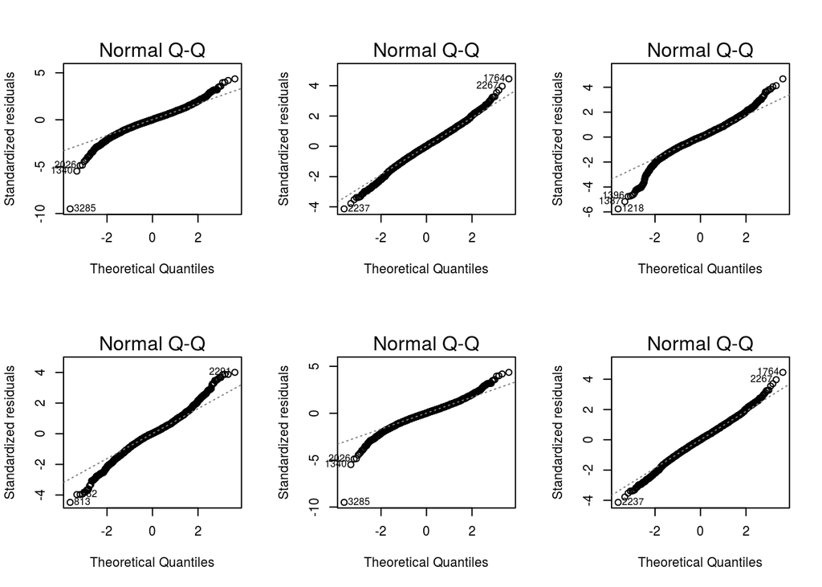

```r
show_plots <- function(names){
  par(mfrow=c(1,1))
  for (i in names){
    plot(lm(cleaned_table[,i]~X_cohort*discrete_age*gender, data=cleaned_table), which=2)
    cat (i, "   ", which(i==names), "   ")
    cat ("Press [enter] to continue.")
    line <- readline()
  }
}

#looking for genes with good qqnorm plot
par(mfrow=c(2,3))
plot(lm(cleaned_table[,best1[1]]~X_cohort*discrete_age*gender, data=cleaned_table), which=2)
plot(lm(cleaned_table[,best1[2]]~X_cohort*discrete_age*gender, data=cleaned_table), which=2)
plot(lm(cleaned_table[,best1[3]]~X_cohort*discrete_age*gender, data=cleaned_table), which=2)
plot(lm(cleaned_table[,best2[1]]~X_cohort*discrete_age*gender, data=cleaned_table), which=2)
plot(lm(cleaned_table[,best2[2]]~X_cohort*discrete_age*gender, data=cleaned_table), which=2)
plot(lm(cleaned_table[,best2[3]]~X_cohort*discrete_age*gender, data=cleaned_table), which=2)
```

Wybralismy geny, dla ktorych mielismy dobry wykres qqnorm, tj odpowiednie kwantyle residuow wychodzily zblizone do kwantyli rozkladu normalnego, a wiec mamy spelnione zalozenia modelu.

```r
#genes, which have nice qqnorm plot
good_qq_1 <- best1[c(2, 8, 12, 14, 16, 18, 31, 32, 37, 41, 64, 66, 69, 72)]
good_qq_2 <- best2[c(3, 4, 5, 9, 10 ,12, 14, 17, 18, 29, 31, 33, 35, 36, 37, 42, 44, 45, 49, 55, 54, 56, 57, 66, 70, 72, 76, 79, 80, 83, 82, 86, 88, 90, 93, 100, 103, 106, 108, 113, 114, 115, 118, 121, 123, 126, 128, 129, 132, 133, 137, 142, 146, 147, 148)]
good_qq_2 <- setdiff(good_qq_2, good_qq_1)
good_qq_2 <- setdiff(good_qq_2, good_qq_1)
```

Spojrzymy jeszcze jak dla tych genow wypadnie test Shapiro-Wilka, ktory jest bardzo czulym testem.

```r
#Shapiro-Wilk normality test
shapiro <- function(i){
  shapiro.test(lm(cleaned_table[,i]~X_cohort*discrete_age*gender, data=cleaned_table)$residuals)$p.value
}
load("good_shapiro_3.RData")
load("good_shapiro_4.RData")
##good_shapiro_3 <- best3[lapply(best3, shapiro) > 0.05]
##good_shapiro_4 <- best4[lapply(best4, shapiro) > 0.05]
```

Spojrzmy na wykresy kwantylowe genow, dla ktorych dostalismy dobry wynik testu Shapiro-Wilka

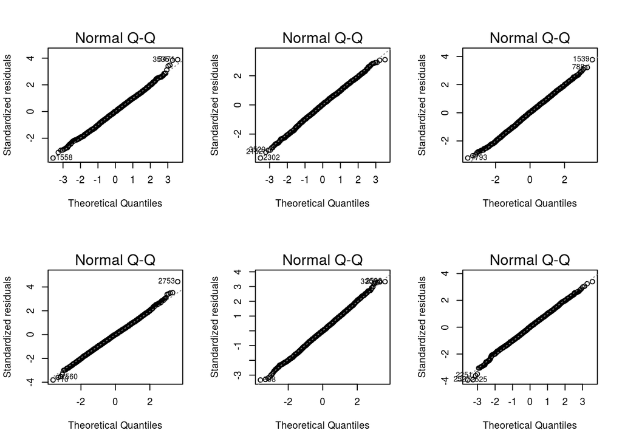

```r
#qqnorm plot for some genes from good_shapiro_3 and good_shapiro_4
par(mfrow=c(2,3))
plot(lm(cleaned_table[,good_shapiro_3[1]]~X_cohort*discrete_age*gender, data=cleaned_table), which=2)
plot(lm(cleaned_table[,good_shapiro_3[2]]~X_cohort*discrete_age*gender, data=cleaned_table), which=2)
plot(lm(cleaned_table[,good_shapiro_3[3]]~X_cohort*discrete_age*gender, data=cleaned_table), which=2)
plot(lm(cleaned_table[,good_shapiro_4[1]]~X_cohort*discrete_age*gender, data=cleaned_table), which=2)
plot(lm(cleaned_table[,good_shapiro_4[2]]~X_cohort*discrete_age*gender, data=cleaned_table), which=2)
plot(lm(cleaned_table[,good_shapiro_4[3]]~X_cohort*discrete_age*gender, data=cleaned_table), which=2)
```

Widzimy, ze istotnie residua maja rozklad podobny do normalnego, spojrzmy zatem dla wybranych dobrych genow (tj tych, dla ktorych prawdopodobnie zachodzi interakcja miedzy grupa rakowa a plcia), ktore grupy mozna odroznic dzieki plci.

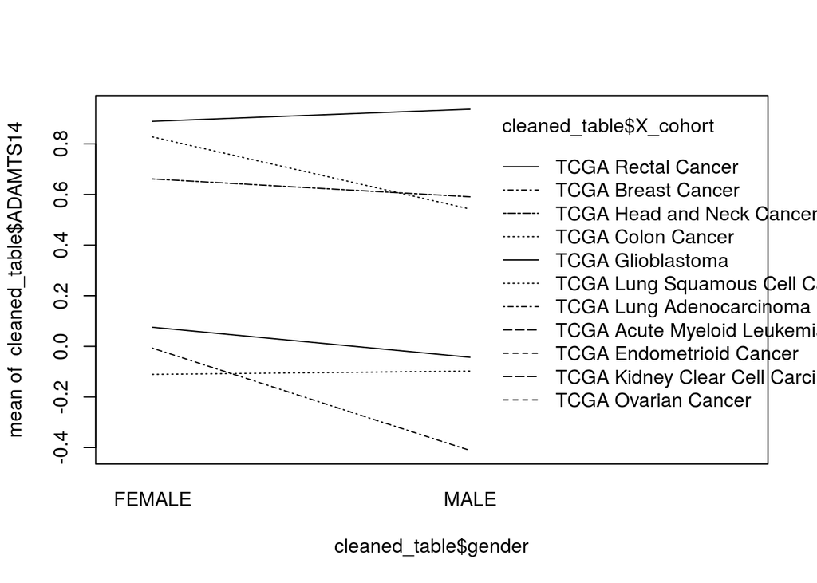

```r
par(mfrow=c(1,1))
interaction.plot(cleaned_table$gender, cleaned_table$X_cohort, cleaned_table$ADAMTS14)
```

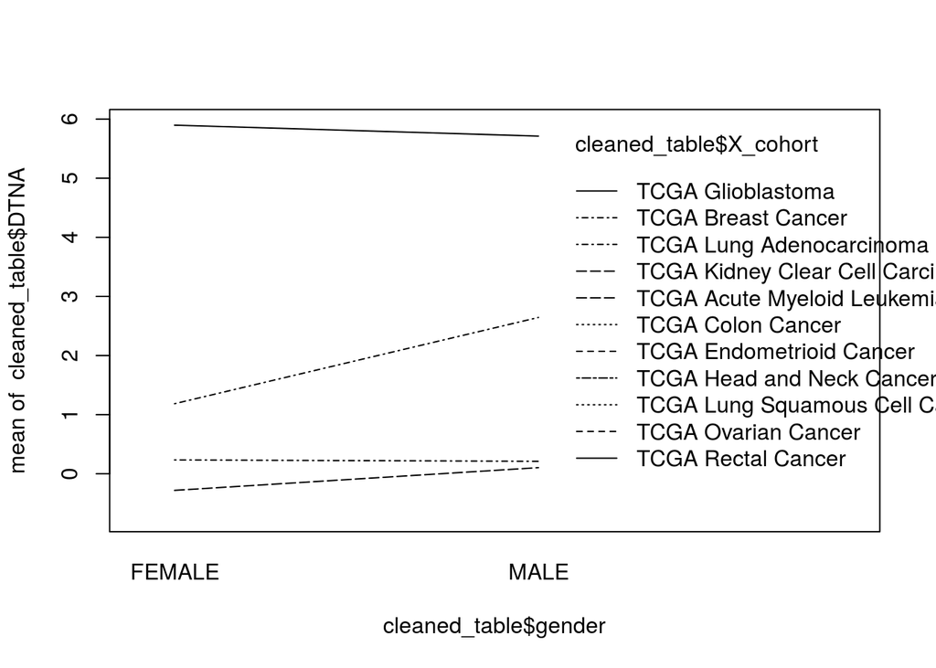

```r
interaction.plot(cleaned_table$gender, cleaned_table$X_cohort, cleaned_table$DTNA)
```

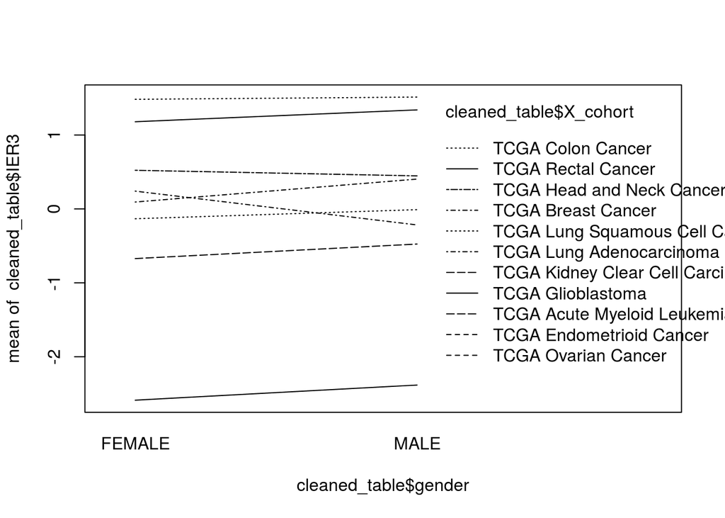

```r
interaction.plot(cleaned_table$gender, cleaned_table$X_cohort, cleaned_table$IER3)
```

Widzimy, ze np dla genu IER3 moglibysmy dzieki plci odroznic Breast i Glioblastone (gdyz tu linie sa najbardziej nierownolegle).

Wykonujemy teraz test Bruscha-Pagana jednorodnosci wariancji. Wypisujemy geny, ktore przeszly oba testy (normalnosc reszt i jednorodnosc wariancji) dla poszczegolnych grup.

```r
BP_1 <- sapply(good_qq_1, function(i) bptest(cleaned_table[,i]~X_cohort*discrete_age*gender, data=cleaned_table)$p.value)
BP_2 <- sapply(good_qq_2, function(i) bptest(cleaned_table[,i]~X_cohort*discrete_age*gender, data=cleaned_table)$p.value)
BP_3 <- sapply(good_shapiro_3, function(i) bptest(cleaned_table[,i]~X_cohort*discrete_age*gender, data=cleaned_table)$p.value)
BP_4 <- sapply(good_shapiro_4, function(i) bptest(cleaned_table[,i]~X_cohort*discrete_age*gender, data=cleaned_table)$p.value)

cancer_age_sex <- good_qq_1[BP_1>=0.04]
cancer_age_AND_cancer_sex <- good_qq_2[BP_2>=0.05]
cancer_age <- good_shapiro_3[BP_3>=0.05]
cancer_sex <- good_shapiro_4[BP_4>=0.05]
cancer_age_sex
```

```
## [1] "ADA"    "NAP1L1" "SNCAIP" "SNX4"   "STX3"
```

```r
cancer_age_AND_cancer_sex
```

```
##  [1] "ATG7"      "BMF"       "C21orf122" "DPY19L1"   "ENOSF1"
##  [6] "FAM115C"   "HTRA3"     "IGJ"       "MED26"     "MEGF6"
## [11] "MYD88"     "RAB32"     "RCC1"      "SEMA3C"    "SNRNP200"
## [16] "SPSB1"     "SYNPO"     "TULP3"     "WDTC1"     "ZDHHC8P1"
## [21] "ZDHHC9"
```

```r
cancer_age
```

```
## [1] "C21orf34" "DACT2"    "FCGBP"    "OTX1"     "TLE6"
```

```r
cancer_sex
```

```
##  [1] "ADAMTS14" "AGAP8"    "ALDH1L1"  "ANKRD58"  "ASPG"     "BTBD11"
##  [7] "C1orf204" "CA4"      "CCDC150"  "CCL3"     "IER3"     "KLF15"
## [13] "MRAP2"    "SIGLEC8"  "ST6GAL2"  "SYT12"
```

# Analiza kontrastow

Teraz bedziemy analizowac kontrasty pomiedzy grupami z interakcja rak-wiek.

```r
library(MASS)
attach(cleaned_table)
age_for_cancer <- function(GEN_nr,NAME_nr){
  count <- length(levels(cleaned_table$discrete_age))
  cancer_name <- levels(X_cohort)[NAME_nr]
  if(sum(X_cohort==as.character(cancer_name)&
           !is.na(cleaned_table[,cancer_age[GEN_nr]]))>0){

    form <- paste(cancer_age[GEN_nr],"discrete_age", sep="~")
    result_table <- summary(lm(as.formula(form),
                               data=cleaned_table[X_cohort==as.character(cancer_name)&
                                                    !is.na(cleaned_table[,cancer_age[GEN_nr]]),],
                               contrasts=list(dose=contr.sdif( count )) ))$coef[-1,c(1,4)]
    which_age <-rownames(result_table)[result_table[,2]<=0.05]
    result_table <- result_table[result_table[,2]<=0.05,]
    if(length(which_age)>0){
      if(length(which_age)>1){
        result_table <- as.data.frame(result_table)
      }else{
        result_table <-as.data.frame(t(as.matrix(result_table)))
      }
      result_table$cancer <- cancer_name
      result_table$discrete_age <- which_age
      result_table$gen <- cancer_age[GEN_nr]
    }else{
      result_table <- NULL
    }
    result_table
  }else{
    NULL
  }
}
#For example
age_for_cancer(4,9)
```

```
##                 Estimate    Pr(>|t|)                            cancer
## discrete_age40 -4.550000 0.006583812 TCGA Lung Squamous Cell Carcinoma
## discrete_age45 -4.172000 0.005362499 TCGA Lung Squamous Cell Carcinoma
## discrete_age49 -4.746667 0.002688581 TCGA Lung Squamous Cell Carcinoma
## discrete_age52 -3.305000 0.047575344 TCGA Lung Squamous Cell Carcinoma
## discrete_age54 -3.815556 0.008083792 TCGA Lung Squamous Cell Carcinoma
## discrete_age57 -3.635000 0.010150554 TCGA Lung Squamous Cell Carcinoma
## discrete_age59 -3.970000 0.007172762 TCGA Lung Squamous Cell Carcinoma
## discrete_age60 -3.960000 0.005765379 TCGA Lung Squamous Cell Carcinoma
## discrete_age62 -3.915385 0.005800427 TCGA Lung Squamous Cell Carcinoma
## discrete_age64 -3.953103 0.004503192 TCGA Lung Squamous Cell Carcinoma
## discrete_age66 -4.048947 0.003933013 TCGA Lung Squamous Cell Carcinoma
## discrete_age68 -4.152609 0.002991245 TCGA Lung Squamous Cell Carcinoma
## discrete_age70 -4.047083 0.003767023 TCGA Lung Squamous Cell Carcinoma
## discrete_age72 -3.421034 0.013754512 TCGA Lung Squamous Cell Carcinoma
## discrete_age74 -3.976071 0.004301996 TCGA Lung Squamous Cell Carcinoma
## discrete_age77 -3.339500 0.016939757 TCGA Lung Squamous Cell Carcinoma
## discrete_age81 -4.087500 0.004109327 TCGA Lung Squamous Cell Carcinoma
##                  discrete_age  gen
## discrete_age40 discrete_age40 OTX1
## discrete_age45 discrete_age45 OTX1
## discrete_age49 discrete_age49 OTX1
## discrete_age52 discrete_age52 OTX1
## discrete_age54 discrete_age54 OTX1
## discrete_age57 discrete_age57 OTX1
## discrete_age59 discrete_age59 OTX1
## discrete_age60 discrete_age60 OTX1
## discrete_age62 discrete_age62 OTX1
## discrete_age64 discrete_age64 OTX1
## discrete_age66 discrete_age66 OTX1
## discrete_age68 discrete_age68 OTX1
## discrete_age70 discrete_age70 OTX1
## discrete_age72 discrete_age72 OTX1
## discrete_age74 discrete_age74 OTX1
## discrete_age77 discrete_age77 OTX1
## discrete_age81 discrete_age81 OTX1
```

```r
n <- length(cancer_age)
m <- length(levels(X_cohort))
risk_age <- lapply(1:(n*m),function(x) {age_for_cancer(x %% n +1,x %% m +1)})

saveRDS(risk_age,"risk_age.rds")

library(plyr)
nonempty <- sapply(1:length(risk_age),function(x) class(risk_age[[x]])=="data.frame")
final_df <- rbind.fill(risk_age[nonempty])

substrRight <- function(x, n){
  substr(x, nchar(x)-n+1, nchar(x))
}

names(final_df)[2] <- "p.value"
final_df$discrete_age <-
  sapply(1:127,function(x)substrRight(final_df$discrete_age[x],2))

final_df[final_df$discrete_age==72,]
```

```
##      Estimate      p.value                            cancer discrete_age
## 1    1.267905 0.0283923163                TCGA Breast Cancer           72
## 29  -3.421034 0.0137545117 TCGA Lung Squamous Cell Carcinoma           72
## 43   1.913182 0.0001347605                TCGA Breast Cancer           72
## 60  -4.655000 0.0130731811                TCGA Rectal Cancer           72
## 81  -3.176000 0.0126722488  TCGA Kidney Clear Cell Carcinoma           72
## 100  6.770000 0.0209768294                TCGA Rectal Cancer           72
## 114  2.097114 0.0006511021                 TCGA Glioblastoma           72
##       gen
## 1   DACT2
## 29   OTX1
## 43  FCGBP
## 60  DACT2
## 81   OTX1
## 100 FCGBP
## 114 FCGBP
```

```r
#saveRDS(final_df,"age_risk_table.rds")
```

# Testy post-hoc

Na koniec wykonamy jeszcze test post-hoc Tukeya, by sprawdzic jakie konkretnie mamy interakcje pomiedzy grupami, sprawdzamy kolejno dla plci, plci i wieku oraz wieku.

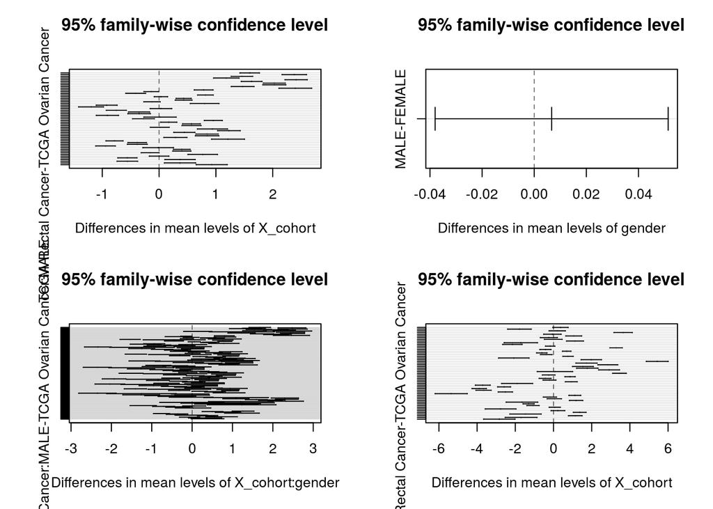

```r
#post hoc testing using Tukey HSD test
par(mfrow=c(2,2))
plot(TukeyHSD(aov(cleaned_table[,1000]~X_cohort*gender, data=cleaned_table)))
plot(TukeyHSD(aov(cleaned_table[,good_shapiro_3[1]]~X_cohort*gender, data=cleaned_table)))
```

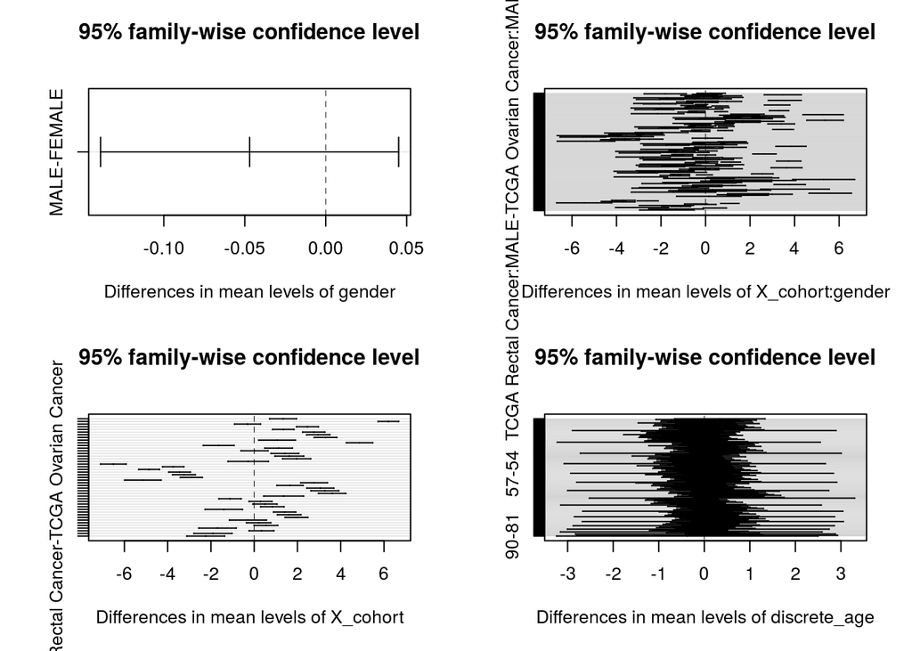

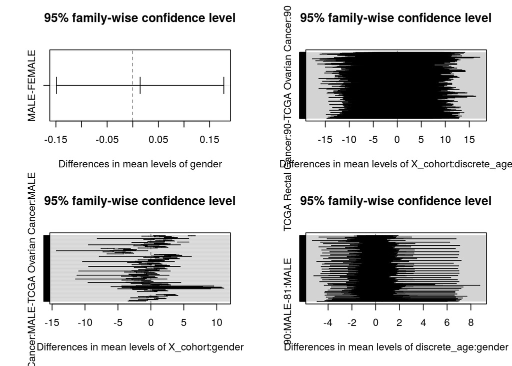

```r
plot(TukeyHSD(aov(cleaned_table[,good_shapiro_3[2]]~X_cohort*discrete_age*gender, data=cleaned_table)))
```

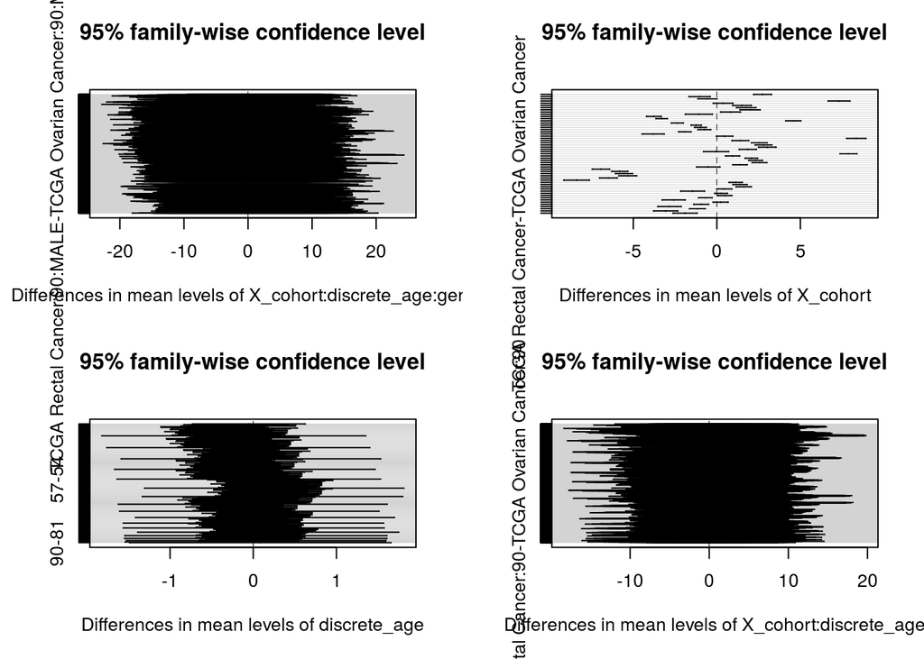

```r
plot(TukeyHSD(aov(cleaned_table[,good_shapiro_3[3]]~X_cohort*discrete_age, data=cleaned_table)))
```